# Course5_Assign1

Tahrul Amin

August 11, 2017

Calling required libraries/R packages

```r
library(dplyr)
library(knitr)
library(lubridate)
library(ggplot2)
library(lattice)
library(markdown)
```

### Part1: Loading and processing the data

```r
setwd("C:/coursera_project/cr5wk2/FINAL")
data <- read.csv("activity.csv", header =TRUE,sep = ',', colClasses =c("numeric","character","integer"))
data$date <- ymd(data$date) #using lubridate package
```

## ———————————————————————————————————-

### Part2: What is mean total number of steps taken per day?

Histogram of the total number of steps taken each day (excluding ‘NA’ values)

```r
steps <- data %>%filter(!is.na(steps)) %>%group_by(date) %>%summarize(steps=sum(steps)) %>%print
```

```
## # A tibble: 53 x 2
##          date steps
##        <date> <dbl>
##  1 2012-10-02   126
##  2 2012-10-03 11352
##  3 2012-10-04 12116
##  4 2012-10-05 13294
##  5 2012-10-06 15420
##  6 2012-10-07 11015
##  7 2012-10-09 12811
##  8 2012-10-10  9900
##  9 2012-10-11 10304
## 10 2012-10-12 17382
## # ... with 43 more rows
```

Including Plots

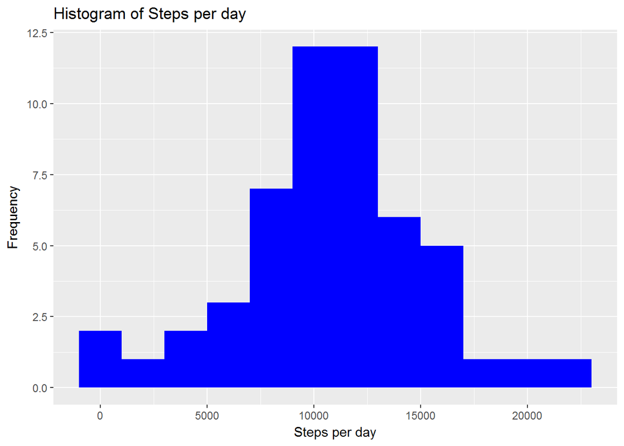

Mean and median number of steps taken each day

```r
mean(steps$steps)
```

```
## [1] 10766.19
```

```r
median(steps$steps)
```

```
## [1] 10765
```

## ——————————————————————————————————–

### Part3: What is the average daily activity pattern?

Time series plot of the average number of steps taken  
Compute the means of steps accross all days for each interval

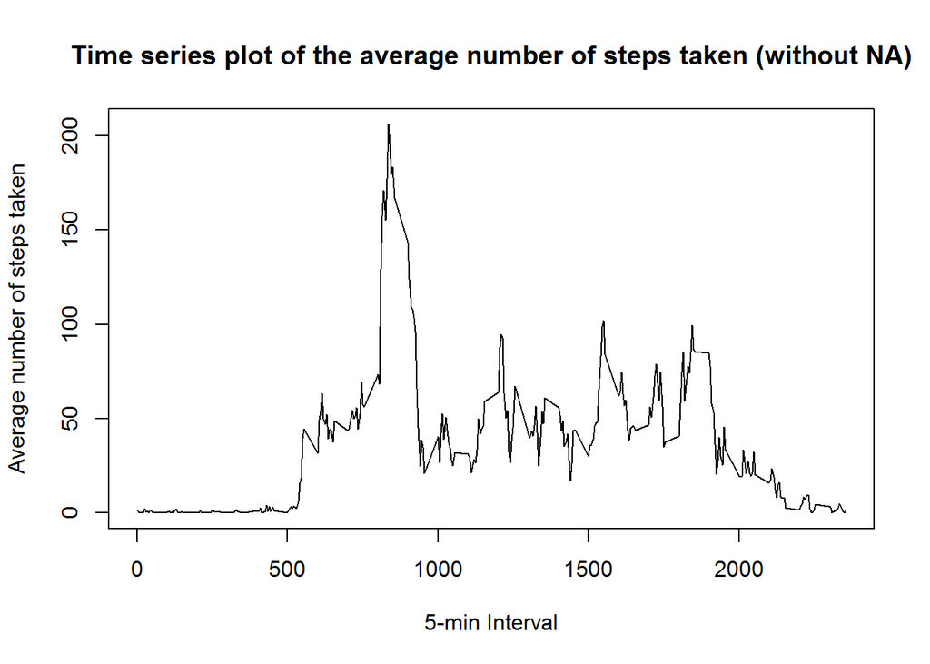

The 5-minute interval that, on average, contains the maximum number of steps

```r
max_index <- which(mean_interval$mean == max(mean_interval$mean))
max_interval <- mean_interval[max_index, 1]
```

max_interval value is 835

## ————————————————————————————————————

### Part4: Imputing missing values

Code to describe and show a strategy for imputing missing data, Histogram

```r
#Reading fresh data
setwd("C:/coursera_project/cr5wk2/FINAL")
data <- read.csv("activity.csv", header =TRUE,sep = ',', colClasses = c("numeric","character","integer"))
data$date <- ymd(data$date)
NA_count <- sum(is.na(data$steps))
# NA count is 2304
na_index <- which(is.na(data$steps))

#keeping very simple, replacing NA by avergae step and put it in one dim array/vector
simple_mean_to_update_NA <- rep(mean(data$steps, na.rm=TRUE), times=NA_count)
#Update dataset with missing values
data[na_index, "steps"] <- simple_mean_to_update_NA
head(data)
```

```
##     steps       date interval
## 1 37.3826 2012-10-01        0
## 2 37.3826 2012-10-01        5
## 3 37.3826 2012-10-01       10
## 4 37.3826 2012-10-01       15
## 5 37.3826 2012-10-01       20
## 6 37.3826 2012-10-01       25
```

Histogram of the total number of steps taken each day (with replaced ‘NA’ values)

```r
steps <- data %>%filter(!is.na(steps)) %>%group_by(date) %>%summarize(steps = sum(steps)) %>%print
```

```
## # A tibble: 61 x 2
##          date    steps
##        <date>    <dbl>
##  1 2012-10-01 10766.19
##  2 2012-10-02   126.00
##  3 2012-10-03 11352.00
##  4 2012-10-04 12116.00
##  5 2012-10-05 13294.00
##  6 2012-10-06 15420.00
##  7 2012-10-07 11015.00
##  8 2012-10-08 10766.19
##  9 2012-10-09 12811.00
## 10 2012-10-10  9900.00
## # ... with 51 more rows
```

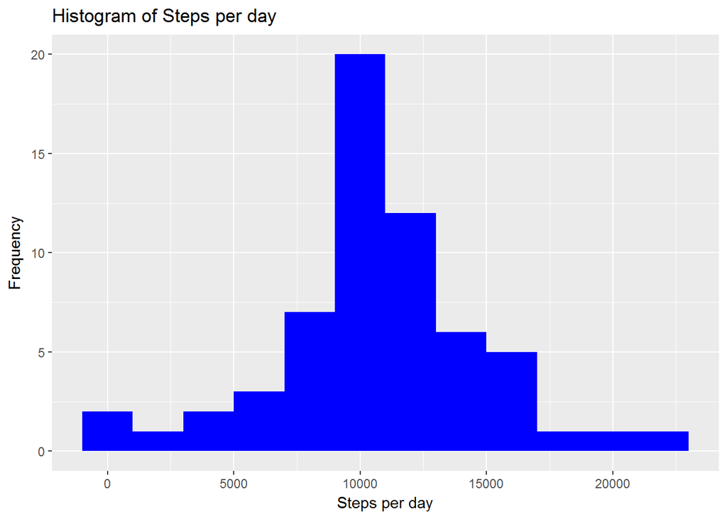

```r
ggplot(steps, aes(x = steps)) +
  geom_histogram(fill = "blue", binwidth = 2000) +
  labs(title = "Histogram of Steps per day", x = "Steps per day", y = "Frequency")
```

mean and median total number of steps taken per day

```r
mean(steps$steps)
```

```
## [1] 10766.19
```

```r
median(steps$steps)
```

```
## [1] 10766.19
```

The mean has not differed from the estimates from the first part of the assignment. The median differed a bit. the impact of imputing missing data on the estimates of the total daily number of steps is low

## ————————————————————————————————————-

## Part-5: Are there differences in activity patterns between weekdays and weekends?

Using the updated dataset with the filled-in missing values find weekdays from the date attribute

```r
updated_dataset <- data.frame(date=data$date, weekday=tolower(weekdays(data$date)), steps=data$steps, interval=data$interval)
# Compute new factor variable 'daytype' (two levels - weekend,weekday) and add this new column using cbind
updated_dataset <- cbind(updated_dataset, daytype=ifelse(updated_dataset$weekday == "saturday" | updated_dataset$weekday == "sunday", "weekend","weekday"))
head(updated_dataset)
```

```
##         date weekday   steps interval daytype
## 1 2012-10-01  monday 37.3826        0 weekday
## 2 2012-10-01  monday 37.3826        5 weekday
## 3 2012-10-01  monday 37.3826       10 weekday
## 4 2012-10-01  monday 37.3826       15 weekday
## 5 2012-10-01  monday 37.3826       20 weekday
## 6 2012-10-01  monday 37.3826       25 weekday
```

```r
# Create the final data frame
final_dataset <- data.frame(date=updated_dataset$date, weekday=updated_dataset$weekday, daytype=updated_dataset$daytype,
                       interval=updated_dataset$interval,
                       steps=data$steps)
```

```r
# Compute the average number of steps taken, averaged across all daytype variable
second_mean_data <- aggregate(final_dataset$steps,
                       by=list(final_dataset$daytype,
                               final_dataset$weekday, final_dataset$interval), mean)

# Rename the attributes
names(second_mean_data) <- c("daytype", "weekday", "interval", "mean")
head(second_mean_data)
```

```
##   daytype  weekday interval     mean
## 1 weekday   friday        0 8.307244
## 2 weekday   monday        0 9.418355
## 3 weekend saturday        0 4.672825
## 4 weekend   sunday        0 4.672825
## 5 weekday thursday        0 9.375844
## 6 weekday  tuesday        0 0.000000
```

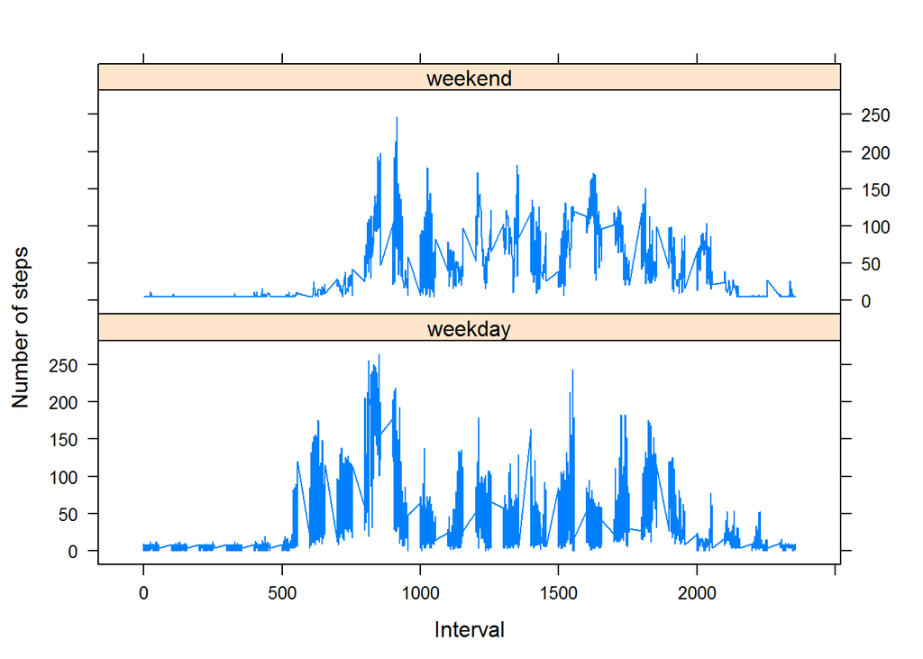

```r
# Compute the time serie plot
xyplot(mean ~ interval | daytype, second_mean_data, type="l",lwd=1,xlab="Interval",ylab="Number of steps",layout=c(1,2))
```